# Factors of savings: Lima Case

## P101

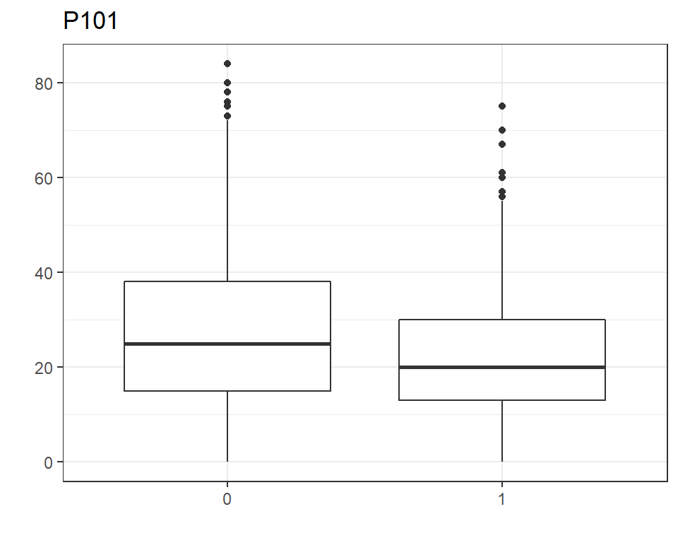

Results of univariate logit

|  | Estimate | Std..Error | z.value | Pr…z.. |
| --- | --- | --- | --- | --- |
| (Intercept) | -1.7800431 | 0.0427473 | -41.64104 | 0 |
| data[, i] | -0.0200611 | 0.0015867 | -12.64338 | 0 |

Odds Ratio

|  | OR | X2.5.. | X97.5.. |
| --- | --- | --- | --- |
| (Intercept) | 0.1686309 | 0.1550230 | 0.1833046 |
| data[, i] | 0.9801388 | 0.9770811 | 0.9831776 |

H0: The coefficient of credFormal is zero  
H1: The coefficient of credFormal is not zero  
Result: Reject H0. With 95% of confidence it could be affirmed that the coefficient of credFormal is not zero

## P102_1

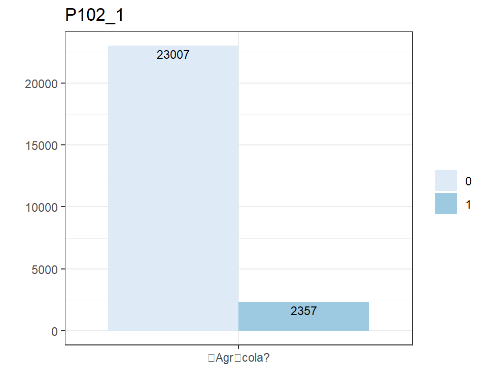

Table of Frequencies

| P102_1 | 0 | % Case | 1 | % Control |
| --- | --- | --- | --- | --- |
| �Agr�cola? | 23007 | 100 | 2357 | 100 |

Chi square test of independence

| Variable | Statistic | Parameter | p.value |
| --- | --- | --- | --- |
| P102_1 | 0 | 0 | 1 |

H0: credFormal and P102_1 are independent  
H1: credFormal and P102_1 are not independent  
Result: Accept H0. With 95% of confidence it could be affirmed that credFormal and P102_1 are independent

## P102_2

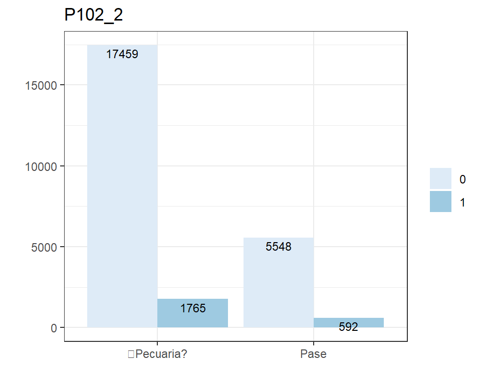

Table of Frequencies

| P102_2 | 0 | % Case | 1 | % Control |
| --- | --- | --- | --- | --- |
| �Pecuaria? | 17459 | 75.89 | 1765 | 74.88 |
| Pase | 5548 | 24.11 | 592 | 25.12 |

Chi square test of independence

| Variable | Statistic | Parameter | p.value |
| --- | --- | --- | --- |
| P102_2 | 1.170571 | 1 | 0.2792839 |

H0: credFormal and P102_2 are independent  
H1: credFormal and P102_2 are not independent  
Result: Accept H0. With 95% of confidence it could be affirmed that credFormal and P102_2 are independent

## P102_3

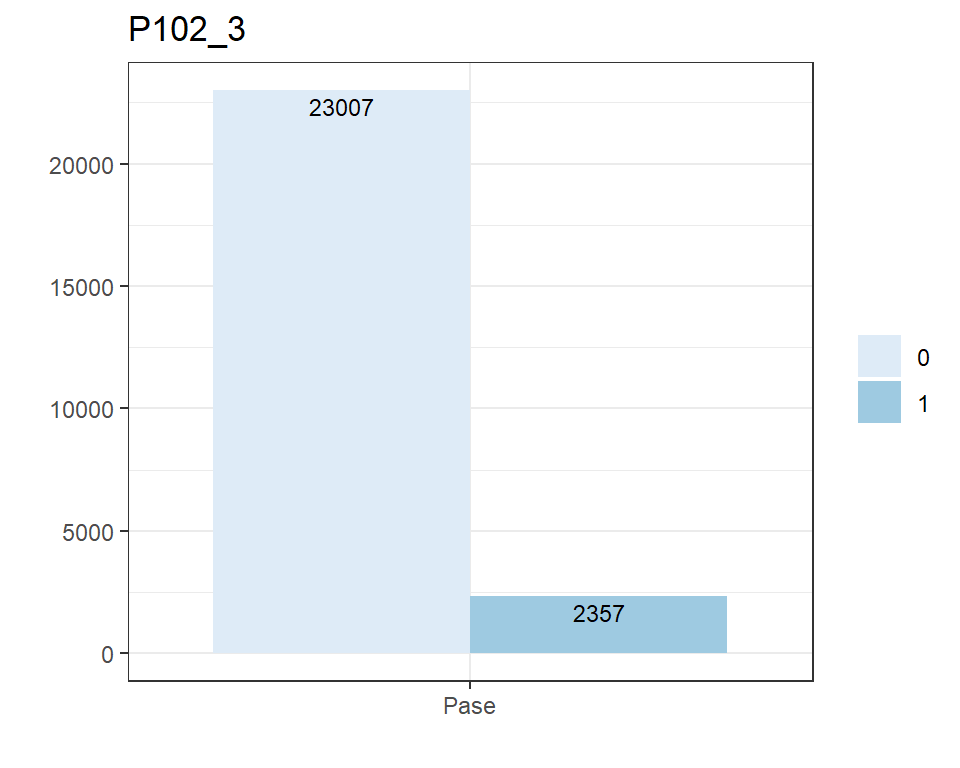

Table of Frequencies

| P102_3 | 0 | % Case | 1 | % Control |
| --- | --- | --- | --- | --- |
| Pase | 23007 | 100 | 2357 | 100 |

Chi square test of independence

| Variable | Statistic | Parameter | p.value |
| --- | --- | --- | --- |
| P102_3 | 0 | 0 | 1 |

H0: credFormal and P102_3 are independent  
H1: credFormal and P102_3 are not independent  
Result: Accept H0. With 95% of confidence it could be affirmed that credFormal and P102_3 are independent

## P104_SUP_ha

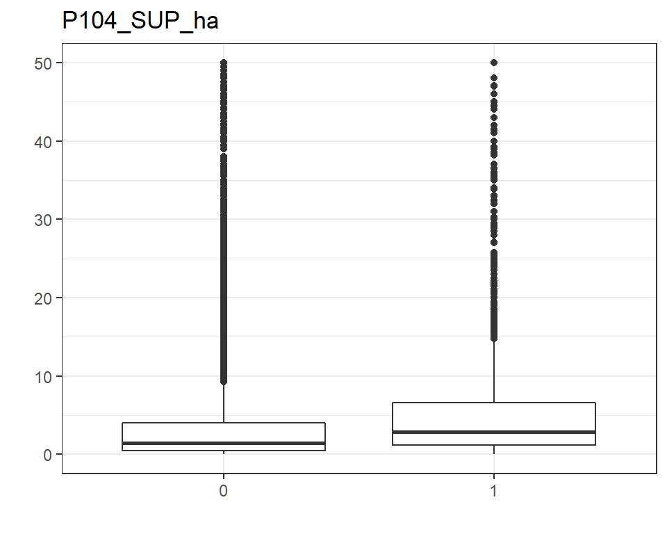

Results of univariate logit

|  | Estimate | Std..Error | z.value | Pr…z.. |
| --- | --- | --- | --- | --- |
| (Intercept) | -2.412263 | 0.0251834 | -95.78772 | 0 |
| data[, i] | 0.027026 | 0.0022350 | 12.09227 | 0 |

Odds Ratio

|  | OR | X2.5.. | X97.5.. |
| --- | --- | --- | --- |
| (Intercept) | 0.0896123 | 0.0852721 | 0.0941199 |
| data[, i] | 1.0273945 | 1.0228543 | 1.0318585 |

H0: The coefficient of credFormal is zero  
H1: The coefficient of credFormal is not zero  
Result: Reject H0. With 95% of confidence it could be affirmed that the coefficient of credFormal is not zero

## prop

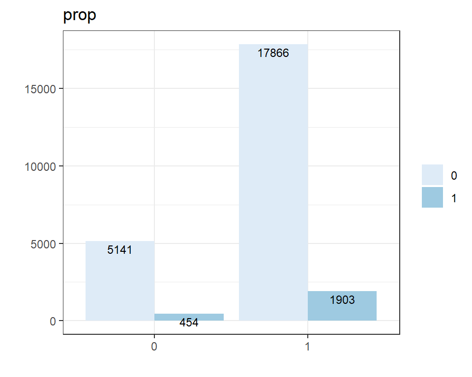

Table of Frequencies

| prop | 0 | % Case | 1 | % Control |
| --- | --- | --- | --- | --- |
| 0 | 5141 | 22.35 | 454 | 19.26 |
| 1 | 17866 | 77.65 | 1903 | 80.74 |

Chi square test of independence

| Variable | Statistic | Parameter | p.value |
| --- | --- | --- | --- |
| prop | 11.82411 | 1 | 0.0005847 |

H0: credFormal and prop are independent  
H1: credFormal and prop are not independent  
Result: Reject H0. With 95% of confidence it could be affirmed that credFormal and prop are not independent

## P801

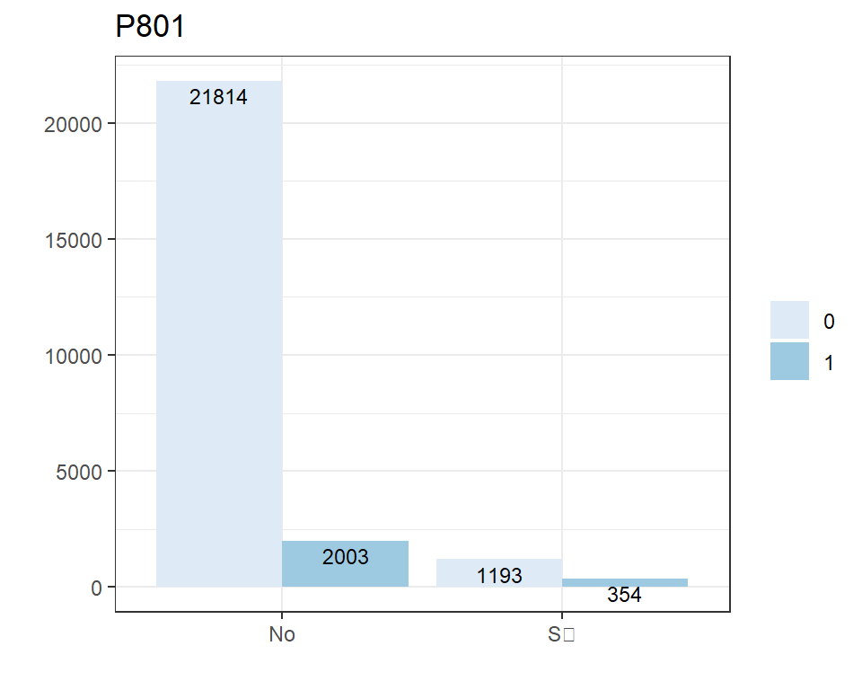

Table of Frequencies

| P801 | 0 | % Case | 1 | % Control |
| --- | --- | --- | --- | --- |
| No | 21814 | 94.81 | 2003 | 84.98 |
| S� | 1193 | 5.19 | 354 | 15.02 |

Chi square test of independence

| Variable | Statistic | Parameter | p.value |
| --- | --- | --- | --- |
| P801 | 360.9899 | 1 | 0 |

H0: credFormal and P801 are independent  
H1: credFormal and P801 are not independent  
Result: Reject H0. With 95% of confidence it could be affirmed that credFormal and P801 are not independent

## P803_1

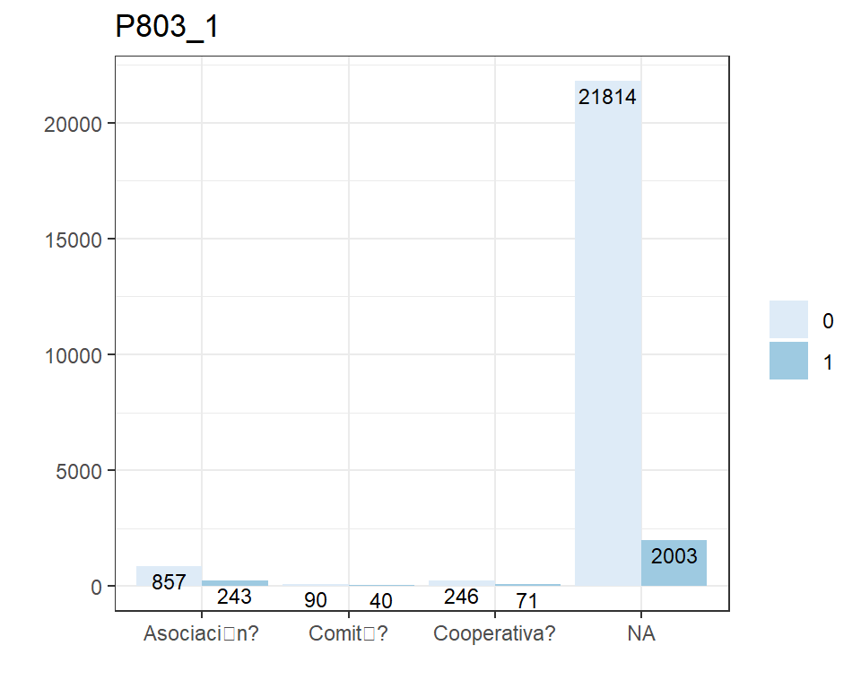

Table of Frequencies

| P803_1 | 0 | % Case | 1 | % Control |
| --- | --- | --- | --- | --- |
| Asociaci�n? | 857 | 71.84 | 243 | 68.64 |
| Comit�? | 90 | 7.54 | 40 | 11.30 |
| Cooperativa? | 246 | 20.62 | 71 | 20.06 |

Chi square test of independence

| Variable | Statistic | Parameter | p.value |
| --- | --- | --- | --- |
| P803_1 | 5.015061 | 2 | 0.0814692 |

H0: credFormal and P803_1 are independent  
H1: credFormal and P803_1 are not independent  
Result: Accept H0. With 95% of confidence it could be affirmed that credFormal and P803_1 are independent

## P901

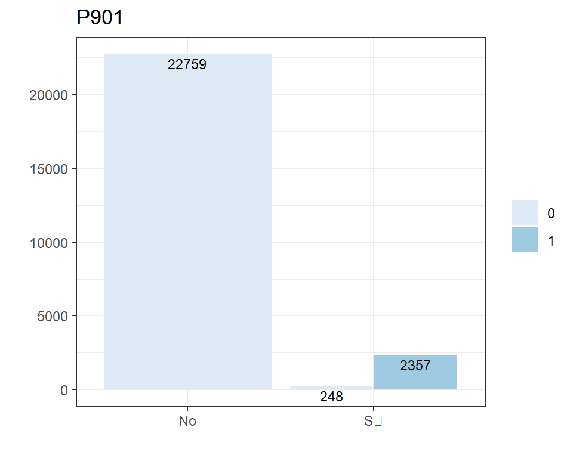

Table of Frequencies

| P901 | 0 | % Case | 1 | % Control |
| --- | --- | --- | --- | --- |
| No | 22759 | 98.92 | 0 | 0 |
| S� | 248 | 1.08 | 2357 | 100 |

Chi square test of independence

| Variable | Statistic | Parameter | p.value |
| --- | --- | --- | --- |
| P901 | 22701.93 | 1 | 0 |

H0: credFormal and P901 are independent  
H1: credFormal and P901 are not independent  
Result: Reject H0. With 95% of confidence it could be affirmed that credFormal and P901 are not independent

## P902

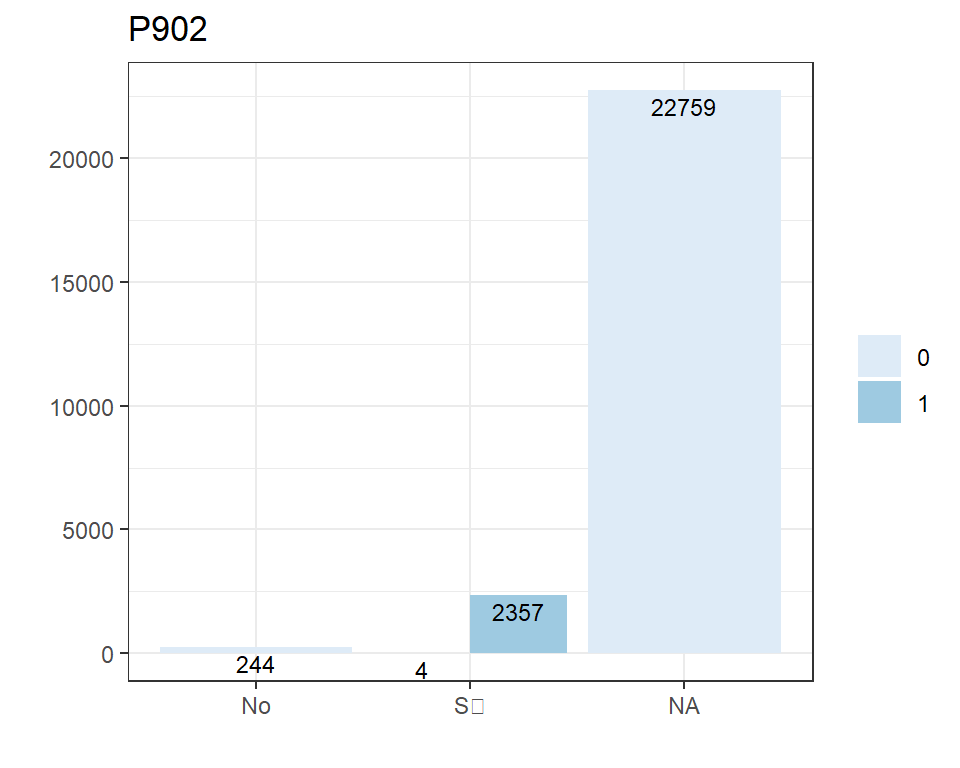

Table of Frequencies

| P902 | 0 | % Case | 1 | % Control |
| --- | --- | --- | --- | --- |
| No | 244 | 98.39 | 0 | 0 |
| S� | 4 | 1.61 | 2357 | 100 |

Chi square test of independence

| Variable | Statistic | Parameter | p.value |
| --- | --- | --- | --- |
| P902 | 2558.642 | 1 | 0 |

H0: credFormal and P902 are independent  
H1: credFormal and P902 are not independent  
Result: Reject H0. With 95% of confidence it could be affirmed that credFormal and P902 are not independent

## P1105

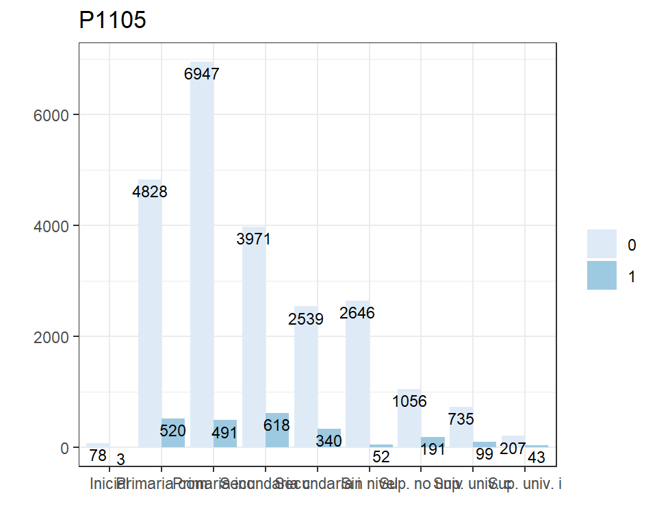

Table of Frequencies

| P1105 | 0 | % Case | 1 | % Control |
| --- | --- | --- | --- | --- |
| Inicial | 78 | 0.34 | 3 | 0.13 |
| Primaria com | 4828 | 20.98 | 520 | 22.06 |
| Primaria inc | 6947 | 30.20 | 491 | 20.83 |
| Secundaria c | 3971 | 17.26 | 618 | 26.22 |
| Secundaria i | 2539 | 11.04 | 340 | 14.43 |
| Sin nivel | 2646 | 11.50 | 52 | 2.21 |
| Sup. no univ | 1056 | 4.59 | 191 | 8.10 |
| Sup. univ. c | 735 | 3.19 | 99 | 4.20 |
| Sup. univ. i | 207 | 0.90 | 43 | 1.82 |

Chi square test of independence

| Variable | Statistic | Parameter | p.value |
| --- | --- | --- | --- |
| P1105 | 437.0436 | 8 | 0 |

H0: credFormal and P1105 are independent  
H1: credFormal and P1105 are not independent  
Result: Reject H0. With 95% of confidence it could be affirmed that credFormal and P1105 are not independent

## P1106

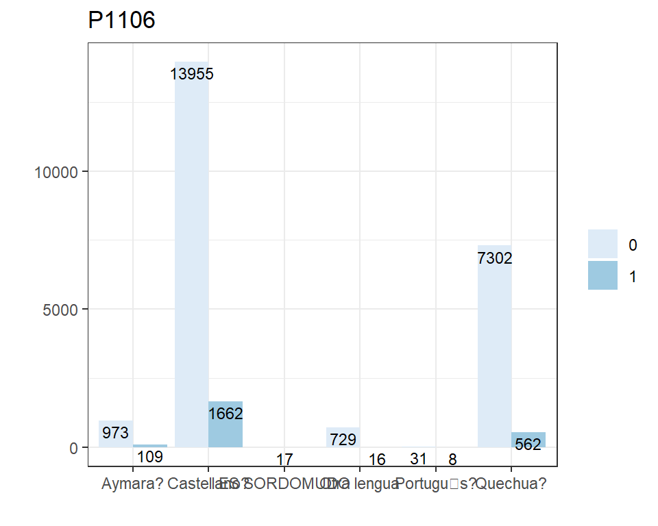

Table of Frequencies

| P1106 | 0 | % Case | 1 | % Control |
| --- | --- | --- | --- | --- |
| Aymara? | 973 | 4.23 | 109 | 4.62 |
| Castellano? | 13955 | 60.66 | 1662 | 70.51 |
| ES SORDOMUDO | 17 | 0.07 | 0 | 0.00 |
| Otra lengua | 729 | 3.17 | 16 | 0.68 |
| Portugu�s? | 31 | 0.13 | 8 | 0.34 |
| Quechua? | 7302 | 31.74 | 562 | 23.84 |

Chi square test of independence

| Variable | Statistic | Parameter | p.value |
| --- | --- | --- | --- |
| P1106 | 130.1885 | 5 | 0 |

H0: credFormal and P1106 are independent  
H1: credFormal and P1106 are not independent  
Result: Reject H0. With 95% of confidence it could be affirmed that credFormal and P1106 are not independent

## P1109A

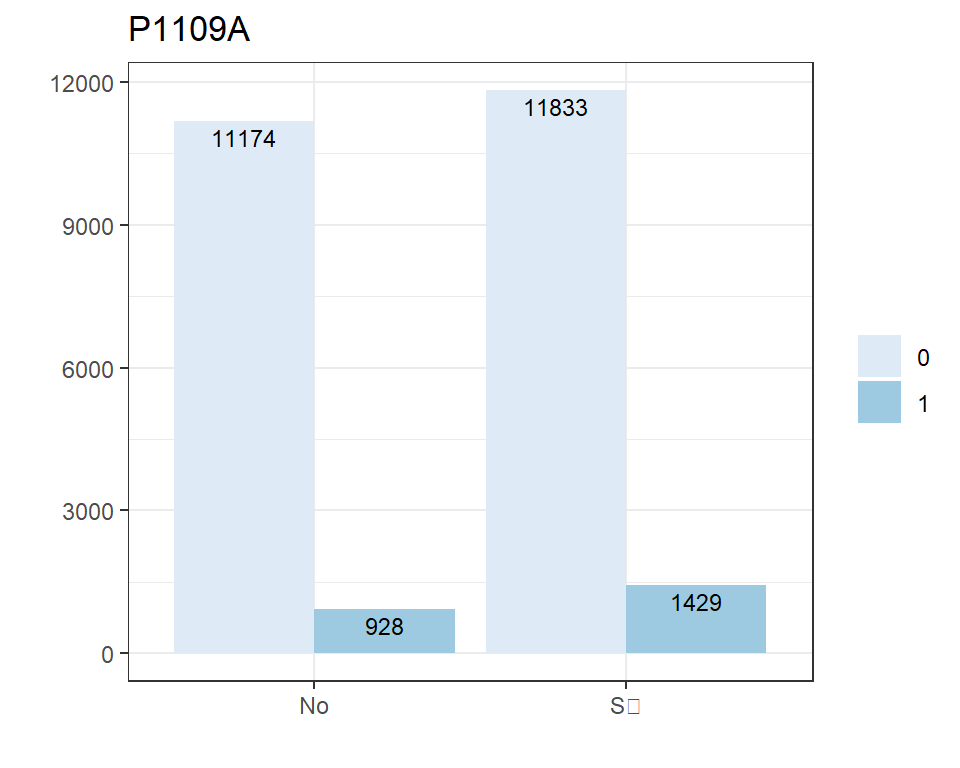

Table of Frequencies

| P1109A | 0 | % Case | 1 | % Control |
| --- | --- | --- | --- | --- |
| No | 11174 | 48.57 | 928 | 39.37 |
| S� | 11833 | 51.43 | 1429 | 60.63 |

Chi square test of independence

| Variable | Statistic | Parameter | p.value |
| --- | --- | --- | --- |
| P1109A | 72.46777 | 1 | 0 |

H0: credFormal and P1109A are independent  
H1: credFormal and P1109A are not independent  
Result: Reject H0. With 95% of confidence it could be affirmed that credFormal and P1109A are not independent

## P1109B

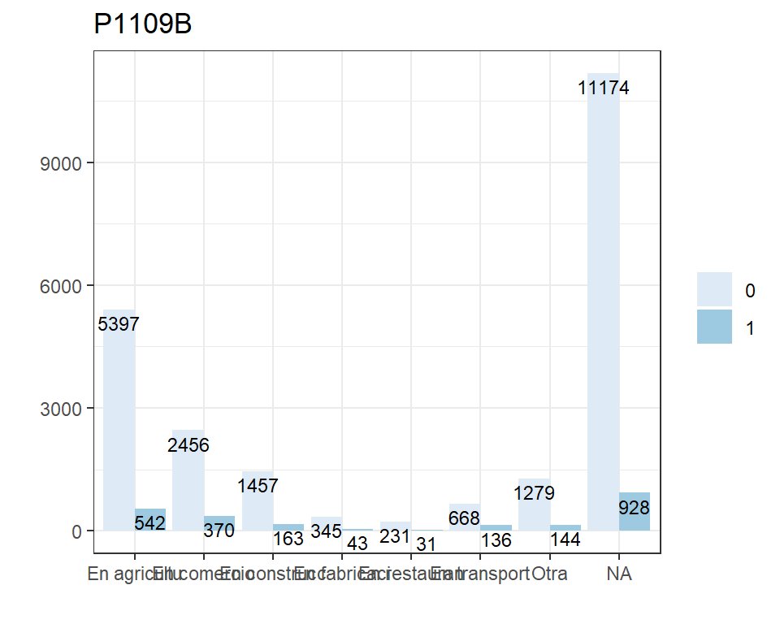

Table of Frequencies

| P1109B | 0 | % Case | 1 | % Control |
| --- | --- | --- | --- | --- |
| En agricultu | 5397 | 45.61 | 542 | 37.93 |
| En comercio | 2456 | 20.76 | 370 | 25.89 |
| En construcc | 1457 | 12.31 | 163 | 11.41 |
| En fabricaci | 345 | 2.92 | 43 | 3.01 |
| En restauran | 231 | 1.95 | 31 | 2.17 |
| En transport | 668 | 5.65 | 136 | 9.52 |
| Otra | 1279 | 10.81 | 144 | 10.08 |

Chi square test of independence

| Variable | Statistic | Parameter | p.value |
| --- | --- | --- | --- |
| P1109B | 65.95255 | 6 | 0 |

H0: credFormal and P1109B are independent  
H1: credFormal and P1109B are not independent  
Result: Reject H0. With 95% of confidence it could be affirmed that credFormal and P1109B are not independent